# Resit 23/24 Q2

*[CEGM1000 MUDE](http://mude.citg.tudelft.nl/)*

## Exercise 1: Programming

**A. Which of the following are correct statements about pandas (the Python library)?**

- It is useful for processing time series data
- It is useful for computing discrete fourier transforms (DFT)
- It uses a dictionary-like syntax
- It has marsupial properties
- It can integrate well with numpy

**Model answer:**

- It is useful for processing time series data
- It uses a dictionary-like syntax
- It can integrate well with numpy

**B. A colleague approaches you with a Python problem, telling you that they have two packages that are not compatible. Which of the following would be a reasonable approach to address this?**

- Reinstall Anaconda
- Restart your computer
- Delete your changes and re-clone your Gitlab repository
- Reactivate your mude environment
- Create a new environment called mude2

**Model answer:**

- Create a new environment called mude2

**C. A snippet of code:**

```
rng = np.random.default_rng()
print(type(rng))
print(rng.random())
```

**produces output:**

```
<class 'numpy.random._generator.Generator'>
0.01628535642909701
```

**Write the output of the following snippet of code, along with a brief explanation (the syntax and value do not need to be perfect):**

`rng.integers(5)`

**Model answer:**

This code will produce a random integer from 0 to 4 (inclusive)  
e.g. `1`

## Exercise 2: Finite Volume Method

Consider the following discretized form of a partial differential equation (PDE), which includes only the component in the x-direction:

$$ \phi^{n+1}_{i,j} = \phi^{n}_{i,j} + \cfrac{C \Delta t}{\Delta x} \left[\cfrac{\partial\phi^{n}_{i,j,E}}{\partial x} - \cfrac{\partial\phi^{n}_{i,j,W}}{\partial x} \right] $$

The domain is divided into square ($\Delta x = \Delta y$) finite volumes, one of which, volume $i,j$ is represented below.

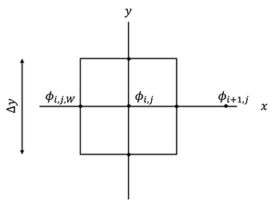

**A. What partial differential equation has been discretized?**

- Advection
- Convection
- Diffusion
- Confusion

**Model answer:**

- Diffusion

**B. Write an expression to approximate the quantity at the East face of the volume $\cfrac{\partial\phi_{i,j,E}}{\partial x}$, which is needed in order to solve the discretized form of the PDE.**

**Model answer:**

$\cfrac{\partial\phi_{i,j,E}}{\partial x} = \cfrac{\phi_{i+1,j} - \phi_{i,j}}{\Delta x}$

## Exercise 3: Finite Element Method

Consider the following code for the computation of an element stiffness matrix with the finite element method in 1D.

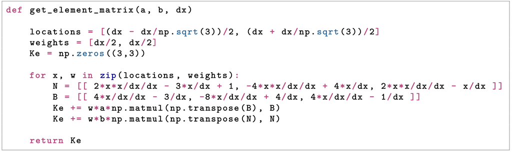

**A. How many nodes does this element have?**

**Model answer:**  
3 nodes

**B. How many integration points are used for computing the element matrix?**

**Model answer:**  
2 integration points

**C. What is the corresponding PDE?**

- $-a\frac{\partial^2u}{\partial x^2} + bu=0$
- $-a\frac{\partial^2u}{\partial x^2} =b$
- $-b\frac{\partial^2u}{\partial x^2} =a$
- $au - b\frac{\partial^2u}{\partial x^2} =0$

**Model answer:**

- $-a\frac{\partial^2u}{\partial x^2} + bu=0$

## Exercise 4: Signal Processing

**We start from a cosine signal with unit amplitude and a frequency of $f_c=3Hz$, and sample it at $f_s=5Hz$, for a duration of $T=2$ seconds. The $N=10$ discrete time samples are input to the Discrete Fourier Transform (DFT) and we directly plot the magnitude (modulus) of the output, hence $|X_k|$ with $k=0,…,N−1$. Create the resulting plot.**

The corresponding Python code is:

```
import numpy as np
from matplotlib import pyplot as plt

fc=3
fs=5
dt=1/fs
T=2
N=T*fs
t=np.arange(0,T,dt)
xt=np.cos(2*np.pi*fc*t)
abs_fft = np.abs(np.fft.fft(xt))
plt.stem(abs_fft)
```

**Model answer:**

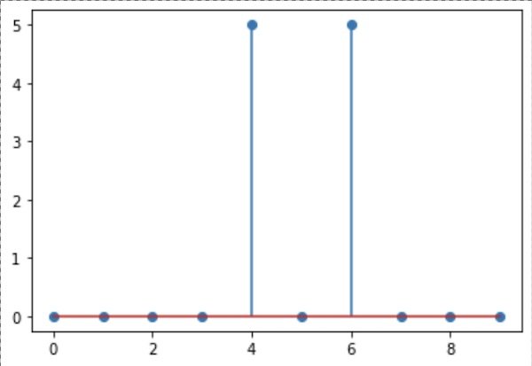

Output frequency range by fft is $[0,f_s)$; $T = 2$ seconds, hence frequency resolution $Df = ½ Hz$. So, we see (discrete) frequencies $[0, ½, 1, 1½, 2, 2½, 3, 3½, 4, 4½]$ in Hz, i.e. up to $f_s (=5Hz)$; or, frequencies $[0, ½, 1, 1½, 2, 2½]$ in $Hz$, when given only up to $f_s/2 (2.5 Hz)$. As the sampling frequency $f_s (=5 Hz)$ is below $2*f_c (f_c=3 Hz)$, we get aliasing. The $3 Hz$ gets mapped onto $2 Hz$ (that’s why it occurs at index 4 in the graph, and also at index 6, which corresponds to frequency $3 Hz$, or, when the spectrum is taken symmetrically from $[-f_s/2,f_s/2)$, it corresponds to $-2 Hz$.

## Exercise 5: Time Series Analysis

We intend to simulate a time series of 200 samples at 1-day intervals (so m=200 and the time unit is a day) using a first-order auto-regressive $AR(1)$ random process $s_t$ as follows: $$ s_t = \beta s_{t-1}+e_t $$

where $t=1,...,m$ and a certain value for $\beta$ are the given $AR(1)$ parameters. We further assume $E(s_t) = 0$ and $D(s_t)=\sigma^2=2$

We simulate data using a normal distribution. To do so, we use the above recursive form, which needs initialization. To initialize the first data, we use:

$$ s_1=s(t=1)=randn(1) $$

Further, the standard deviation of the random noise $e_t$ can be obtained from: $$ \sigma_e^2 = \sigma^2(1-\beta^2) $$

A time series simulation versus time is shown in the plot below. The horizontal axis shows the time in units of day.

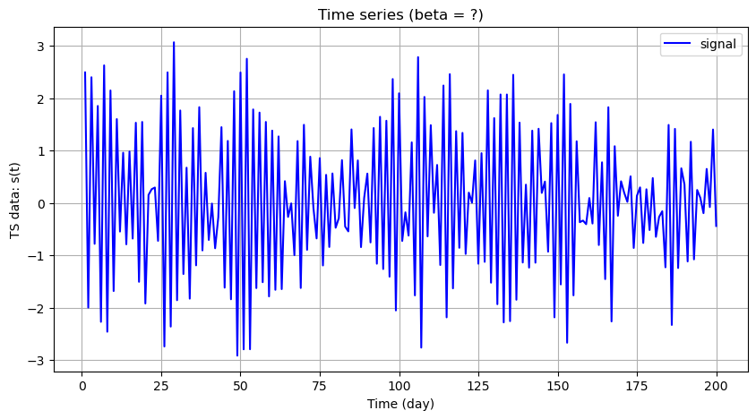

The following is a printed array of 10 consecutive samples from the time series:

```
10 consecutive sample values from time series:
[ 2.49474675 -1.99859861 2.40207336 -0.78048668 1.85367808
-2.27074481 2.62934417 -2.4597126 2.15011297 -1.68199175]
```

*Given the information and the plot above, answer the following questions.*

**A. What can you say about the type of noise?**

- White
- Colored
- Grey

**Model answer:**

- Colored

**B. Sketch the normalized auto-covariance function (ACF) of the generated time series above. Include the following in your plot:**

- clearly labelled axes (ACF and time lag)
- a standard stem plot for each time lag (include at least 5 stems)
- besides being within appropriate numerical bounds, the absolute value of the ACF is not important; however, make sure it is possible to clearly distinguish whether the value is positive, negative or zero
- you do not need to include the confidence interval

**Model answer:**

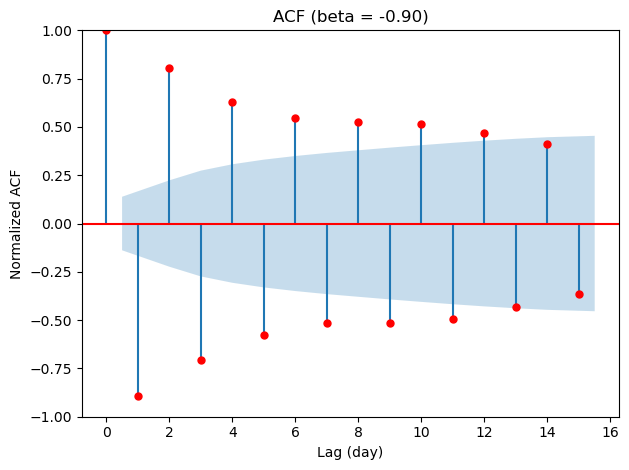

**C. What would the parameters of $x$ be? Stated in a different way: what components are clearly visible in the time series?**

- Noise
- Correlation
- Trend
- Drift
- Bias
- Seasonality
- Irregularities/outliers
- Offset
- Derivative

## Exercise 6: Optimization

**Consider the following optimization problem:** $$ Maximize \, Z = 3x_1+2x_2 $$

**Subject to:** $$ 2x_1+x_2\leq18 \\ -4x_1+5x_2\leq10 \\ x_1, x_2 \geq0 \ $$ **Convert the problem into its augmented form and then, if needed, find a next basic solution. Explain the process and the steps taken. After finding a new basic solution (if applicable), determine the current values of the objective function and all decision variables. State if this new solution is the optimal solution or not.**

**Model answer:**

**Convert to augmented form:**

$$2x_1 + x_2 + s_1 = 18$$
$$-4x_1 + 5x_2 + s_2 = 10$$

**Fill the table:**

|  | Z | x1 | x2 | s1 | s2 | b |
| --- | --- | --- | --- | --- | --- | --- |
| Z | 1 | -3 | -2 | 0 | 0 | 0 |
| s1 | 0 | 2 | 1 | 1 | 0 | 18 |
| s2 | 0 | -4 | 5 | 0 | 1 | 10 |

Since both coefficients of the objective functions are negative (-3 and -2), the solution is not optimal.  
$x_1$ enters the basis because it has the most negative coefficient.

**Apply the minimum ratio test:**

For $s_1$: $\frac{18}{2} = 9$, for $s_2$: $\frac{10}{-4} = -2.5$.  
$s_1$ leaves the basis ($s_2$ is not a candidate because it is negative).

Change the current system to an equivalent one with the following steps:

- Divide the second row by 2 to get the $x_1$ coefficient equal to 1. Result:

$$0 \quad 1 \quad \frac{1}{2} \quad \frac{1}{2} \quad 0 \quad 9$$

- Multiply the new second row by 4 and sum it to the third row to get the $x_1$ coefficient equal to 0. Result:

$$0 \quad 0 \quad 7 \quad 2 \quad 1 \quad 46$$

- Multiply the same row by 3 and sum it to the first row to get the $x_1$ coefficient equal to 0. Result:

$$ 1 \quad 0 \quad -\frac{1}{2} \quad \frac{3}{2} \quad 0 \quad 27 $$

- Finally, combine the new rows. The new table is this:

|  | Z | x1 | x2 | s1 | s2 | b |
| --- | --- | --- | --- | --- | --- | --- |
| Z | 1 | 0 | -1/2 | 3/2 | 0 | 27 |
| x1 | 0 | 1 | 1/2 | 1/2 | 0 | 9 |
| s2 | 0 | 0 | 7 | 2 | 1 | 46 |

This is not the optimal solution yet, because it's a maximization problem and there is still a negative coefficient in the row of the objective function in the column of a non-basic variable.

## Exercise 7: Machine Learning

**A. Consider the following kNN model trained on 100 noisy observations of a target function:**

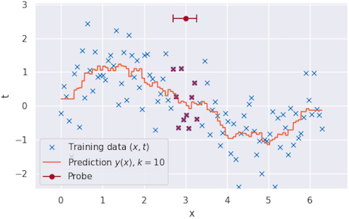

**where points in red represent the neighborhood used to make a prediction at $x=3$. From classical decision theory, we are interested in minimizing the expected loss** $$ \mathbb{E}\left[L\right] = \int\int\left(y(x)-t\right)^2p(x,t)\,\mathrm{d}x\mathrm{d}t $$ **which from variational calculus yields the result:** $$ y(x) = \mathbb{E}_t\left[t\vert x\right] $$

**Regarding the aforementioned decision theory concepts and the kNN model above, which __ONE** of the following statements is true?__

- Looking at how $\mathbb{E}\left[L\right]$ changes as a function of $k$ we see that using higher values of $k$ will in general lead to lower losses, as that corresponds to more flexible models
- When using kNN to predict at the edges of the dataset (around $x=0$ or $x=6.3$), we expect the function $\mathbb{E}_t\left[t\vert x\right]$ to become much more sensitive to small changes in $x$ because there will be less samples in their neighborhood
- We can decompose $\mathbb{E}\left[L\right]$ into a bias term, a variance term and a noise term. For kNN, the value of $k=1$ corresponds to the model with the highest possible bias, and therefore also the highest possible variance
- The function $y(x)$ obtained by kNN is an approximation of $y(x)=\mathbb{E}_t\left[t\vert x\right]$: the distribution $p(t\vert x=3)$ is approximated by the samples in red, while the expectation is approximated by averaging over these samples

**Model answer:**

- The function $y(x)$ obtained by kNN is an approximation of $y(x)=\mathbb{E}_t\left[t\vert x\right]$: the distribution $p(t\vert x=3)$ is approximated by the samples in red, while the expectation is approximated by averaging over these samples

**B. Regarding the use of feedforward neural networks for regression, which ONE of the following statements is true?**

- $L_2$ regularization can be used to alleviate overfitting, consisting in the inclusion of a $\frac{\lambda}{2}\mathbf{w}^\mathrm{T}\mathbf{w}$ term to the loss function. The lower $\lambda$ is, the more rigid the model will become (higher bias)
- The choice of activation function can make a neural network model more or less flexible. At the high-bias limit, setting the activations of all layers to linear will make the network behave exactly like a simple linear regression model
- Neural networks can be seen as extensions of linear basis function models: in basis function models the mappings $\phi(\mathbf{x})$ are linear functions of $\mathbf{x}$ while in neural networks those can become nonlinear
- Neural networks are universal approximators and can therefore fit any continuum function to any arbitrary level of accuracy. This means that by introducing enough flexibility to the network we can always bring $\mathbb{E}\left[L\right]$ as close to zero as we want

**Model answer:**

- The choice of activation function can make a neural network model more or less flexible. At the high-bias limit, setting the activations of all layers to linear will make the network behave exactly like a simple linear regression model

- With minibatch SGD, each model update is performed with a number of samples larger than the original size of the dataset, which means some samples will appear more than once in the batch
- The stochastic nature of SGDs comes from the fact that updates are done with random subsets of the dataset. Nevertheless, the algorithm guarantees the full dataset will always be seen by the model, at which point we say that an epoch has passed
- An important parameter in SGD is the **learning rate** $\eta$. High values of $\eta$ lead to more gradual (slower) changes in $\mathbf{w}$ after every update. Lower values are therefore preferred because that leads to faster convergence
- When using SGD, it is interesting to keep track of the training progress by computing the loss function on all training samples, even though model weights are updated exclusively on gradients computed using the validation dataset

**Model answer:**

- The stochastic nature of SGDs comes from the fact that updates are done with random subsets of the dataset. Nevertheless, the algorithm guarantees the full dataset will always be seen by the model, at which point we say that an epoch has passed

## Exercise 8: Extreme Value Analysis

General information about extreme value distributions is provided below. Think of it like a formula sheet. You may not need this information for all questions, and may not need all of it.

Recall that the Generalized Extreme Value distribution can be written as follows:

$$ P[X < x] = \exp\left( - \left[ 1 + \xi \frac{x - \mu}{\sigma} \right]^{-1/\xi} \right) $$

subject to the condition:

$$ \left( 1 + \xi \frac{x - \mu}{\sigma} \right) > 0 $$

where the random variable $X$ is defined by the location, scale, and shape parameters $\mu$, $\sigma$, and $\xi$, respectively.

The design value $x$ for annual (yearly) probability of non-exceedance $p_y$ is:

$$ x = \begin{cases} \mu - \frac{\sigma}{\xi}\left[ 1 - \left( -\ln(1-p_y) \right)^{-\xi} \right] & \xi \neq 0 \\ \mu - \sigma \ln\left(1-p_y\right) & \xi = 0 \end{cases} $$

with the design life probability over $DL$ years given as:

$$ p_{DL} = 1 - (1 - p_y)^{DL} $$

Recall that the Generalized Pareto distribution can be written as follows for a random variable $X$ with parameters $th$ (threshold), shape $\xi$, and scale $\sigma_{th}$:

$$ P[X < x | X > th] = \begin{cases} 1 - \left(1 + \xi \frac{x - th}{\sigma_{th}}\right)^{-1/\xi} & \xi \neq 0 \\ 1 - \exp\left(-\frac{x - th}{\sigma_{th}}\right) & \xi = 0 \end{cases} $$

The design value $x_N$ for an $N$-years return level is:

$$ x_N = \begin{cases} th + \frac{\sigma_{th}}{\xi}\left[(\lambda_N)^{\xi} - 1\right] & \xi \neq 0 \\ th + \sigma_{th} \ln(\lambda_N) & \xi = 0 \end{cases} $$

where $\lambda$ is the average number of excesses during the observation period, and $N$ is the $N$-years return level.

As a consultant, you need to design a water treatment plant. There are different variables that need to be considered to this end: (1) the incoming water discharge to treat denoted as $Q$, (2) the concentration of organic matter denoted as $C$, and (3) the concentration of inorganic matter denoted as $M$.

You start studying the discharge $Q$, and you want to model the maximum yearly discharge (our random variable of interest). You managed to get a time series and when you start processing the sampled observations, you detect a trend around the mean (see Figure).

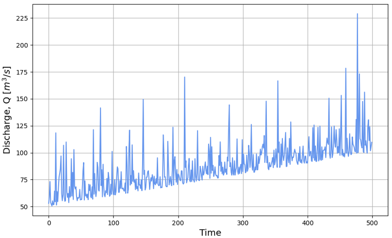

**A. Which of the following properties is clearly not satisfied by the data:**

- Independent
- Identically distributed
- Asymmetry
- Mutually exclusive
- Collectively exhaustive

**Model answer:**

- Identically distributed

**B. Can you apply Extreme Value Analysis to those observations of $Q$ as they are?**

- Yes
- No

**Model answer:**

- No

Since you are not sure how to proceed with the discharge $Q$ you move to the next variable, the concentration $C$.

**C. You have been studying $C$ for a long time (many years) and you know the distribution it follows, $C∼F(c)$. What is the distribution of monthly maxima of $C$? Assume that $C$ are daily observations and $N$ is the number of observations per year.**

- $F(c)^N$
- $F(c)^{N/12}$
- $F(c)^{12N}$
- $F(c)^{N/30}$

**Model answer:**

- $F(c)^{N/12}$

**D. Compute the design value for a return period of 25 years.**

**Model answer:**

$$ x = \mu - \frac{\sigma}{\xi} \left[1 - \left(-\ln(1-p_y)\right)^{-\xi}\right] = 3 - \frac{0.5}{0.25} \left[1 - \left(-\ln\left(1-\frac{1}{25 \times 12}\right)\right)^{-0.25}\right] = 9.3 \text{ mg/L} $$

## Exercise 9: Risk and Reliability

Your answer should look like this (one sentence each, max):

- example of what to do
- quantitative effect on consequence, probability or limit line

**Example answers:**

- prevent people from drinking water after the spill; reduces consequences
- install a spill containment system; reduces consequences
- improve the reliabiltiy of the chemical thing; reduce probability of failure
- change the policy to accept more people getting sick; increase limit line